# Rupesh Singh - Ensemble Techniques

## Goal

#### Using the data collected from existing customers, build a model that will help the marketing team identify potential customers who are relatively more likely to subscribe term deposit and thus increase their hit ratio.

### Attribute information

Input variables: Bank client data:

1. age: Continuous feature
2. job: Type of job (management, technician, entrepreneur, blue-collar, etc.)
3. marital: marital status (married, single, divorced)
4. education: education level (primary, secondary, tertiary)
5. default: has credit in default?
6. housing: has housing loan?
7. loan: has personal loan?
8. balance in account Related to previous contact:
9. contact: contact communication type
10. month: last contact month of year
11. day: last contact day of the month
12. duration: last contact duration, in seconds* Other attributes:
13. campaign: number of contacts performed during this campaign and for this client
14. pdays: number of days that passed by after the client was last contacted from a previous campaign (-1 tells us the person has not been contacted or contact period is beyond 900 days)
15. previous: number of times the client has been contacted before for the last campaign to subscribe term deposit
16. poutcome: outcome of the previous marketing campaign Output variable (desired target):
17. Target: Tell us has the client subscribed a term deposit. (Yes, No)

```python
import warnings
warnings.filterwarnings('ignore')   # to avoid warnings
```

```python
import pandas as pd

#importing the Encoding library
from sklearn.preprocessing import LabelEncoder

#Import Decision Tree Classifier machine learning Library
from sklearn.tree import DecisionTreeClassifier

# Import Logistic Regression machine learning library
from sklearn.linear_model import LogisticRegression

#Import Sklearn package's data splitting function which is based on random function
from sklearn.model_selection import train_test_split

#Import the metrics
from sklearn import metrics

# importing ploting libraries
import matplotlib.pyplot as plt

# To enable plotting graphs in Jupyter notebook
%matplotlib inline

#importing seaborn for statistical plots
import seaborn as sns

#importing Sklearn package's data splitting function which is based on random function
from sklearn.model_selection import train_test_split

import numpy as np
from scipy import stats

# To calculate accuracy measures and confusion matrix
from sklearn import metrics

# install yellowbrick and graohviz
import graphviz
from yellowbrick.classifier import ClassificationReport, ROCAUC
```

```python
# importing data set

data = pd.read_csv("bank-full.csv")
data.head()
```

|  | age | job | marital | education | default | balance | housing | loan | contact | day | month | duration | campaign | pdays | previous | poutcome | Target |
| --- | --- | --- | --- | --- | --- | --- | --- | --- | --- | --- | --- | --- | --- | --- | --- | --- | --- |
| 0 | 58 | management | married | tertiary | no | 2143 | yes | no | unknown | 5 | may | 261 | 1 | -1 | 0 | unknown | no |
| 1 | 44 | technician | single | secondary | no | 29 | yes | no | unknown | 5 | may | 151 | 1 | -1 | 0 | unknown | no |
| 2 | 33 | entrepreneur | married | secondary | no | 2 | yes | yes | unknown | 5 | may | 76 | 1 | -1 | 0 | unknown | no |
| 3 | 47 | blue-collar | married | unknown | no | 1506 | yes | no | unknown | 5 | may | 92 | 1 | -1 | 0 | unknown | no |
| 4 | 33 | unknown | single | unknown | no | 1 | no | no | unknown | 5 | may | 198 | 1 | -1 | 0 | unknown | no |

### Deliverable – 1 (Exploratory data quality report reflecting the following) – (20)

1. Univariate analysis (12 marks)  
   a. Univariate analysis – data types and description of the independent attributes which should include (name, meaning, range of values observed, central values (mean and median), standard deviation and quartiles, analysis of the body of distributions / tails, missing values, outliers.  
   b. Strategies to address the different data challenges such as data pollution, outlier’s treatment and missing values treatment.  
   c. Please provide comments in jupyter notebook regarding the steps you take and insights drawn from the plots.

```python
# get data information
data.info()
```

```
<class 'pandas.core.frame.DataFrame'>
RangeIndex: 45211 entries, 0 to 45210
Data columns (total 17 columns):
 #   Column     Non-Null Count  Dtype
---  ------     --------------  -----
 0   age        45211 non-null  int64
 1   job        45211 non-null  object
 2   marital    45211 non-null  object
 3   education  45211 non-null  object
 4   default    45211 non-null  object
 5   balance    45211 non-null  int64
 6   housing    45211 non-null  object
 7   loan       45211 non-null  object
 8   contact    45211 non-null  object
 9   day        45211 non-null  int64
 10  month      45211 non-null  object
 11  duration   45211 non-null  int64
 12  campaign   45211 non-null  int64
 13  pdays      45211 non-null  int64
 14  previous   45211 non-null  int64
 15  poutcome   45211 non-null  object
 16  Target     45211 non-null  object
dtypes: int64(7), object(10)
memory usage: 5.9+ MB
```

```python
# get data types
data.dtypes
```

```
age           int64
job          object
marital      object
education    object
default      object
balance       int64
housing      object
loan         object
contact      object
day           int64
month        object
duration      int64
campaign      int64
pdays         int64
previous      int64
poutcome     object
Target       object
dtype: object
```

```python
# describe the data using statistical summary
data.describe()
```

|  | age | balance | day | duration | campaign | pdays | previous |
| --- | --- | --- | --- | --- | --- | --- | --- |
| count | 45211.000000 | 45211.000000 | 45211.000000 | 45211.000000 | 45211.000000 | 45211.000000 | 45211.000000 |
| mean | 40.936210 | 1362.272058 | 15.806419 | 258.163080 | 2.763841 | 40.197828 | 0.580323 |
| std | 10.618762 | 3044.765829 | 8.322476 | 257.527812 | 3.098021 | 100.128746 | 2.303441 |
| min | 18.000000 | -8019.000000 | 1.000000 | 0.000000 | 1.000000 | -1.000000 | 0.000000 |
| 25% | 33.000000 | 72.000000 | 8.000000 | 103.000000 | 1.000000 | -1.000000 | 0.000000 |
| 50% | 39.000000 | 448.000000 | 16.000000 | 180.000000 | 2.000000 | -1.000000 | 0.000000 |
| 75% | 48.000000 | 1428.000000 | 21.000000 | 319.000000 | 3.000000 | -1.000000 | 0.000000 |
| max | 95.000000 | 102127.000000 | 31.000000 | 4918.000000 | 63.000000 | 871.000000 | 275.000000 |

```python
# getting data shape
data.shape
```

```
(45211, 17)
```

```python
# checking null values
data.isnull().values.any()
```

```
False
```

```python
data.tail()
```

|  | age | job | marital | education | default | balance | housing | loan | contact | day | month | duration | campaign | pdays | previous | poutcome | Target |
| --- | --- | --- | --- | --- | --- | --- | --- | --- | --- | --- | --- | --- | --- | --- | --- | --- | --- |
| 45206 | 51 | technician | married | tertiary | no | 825 | no | no | cellular | 17 | nov | 977 | 3 | -1 | 0 | unknown | yes |
| 45207 | 71 | retired | divorced | primary | no | 1729 | no | no | cellular | 17 | nov | 456 | 2 | -1 | 0 | unknown | yes |
| 45208 | 72 | retired | married | secondary | no | 5715 | no | no | cellular | 17 | nov | 1127 | 5 | 184 | 3 | success | yes |
| 45209 | 57 | blue-collar | married | secondary | no | 668 | no | no | telephone | 17 | nov | 508 | 4 | -1 | 0 | unknown | no |
| 45210 | 37 | entrepreneur | married | secondary | no | 2971 | no | no | cellular | 17 | nov | 361 | 2 | 188 | 11 | other | no |

**Insights**

1. The object type columns needs to be converted to categorical type variables
2. No missing values found
3. Age, balance and duration fields seems to have outliers
4. Categorical variables doesn't seem to have issues

```python
# converting object type to categorical variables
for c in data.columns:
    if data[c].dtype=='object':
        data[c]=pd.Categorical(data[c])
data.head()
```

|  | age | job | marital | education | default | balance | housing | loan | contact | day | month | duration | campaign | pdays | previous | poutcome | Target |
| --- | --- | --- | --- | --- | --- | --- | --- | --- | --- | --- | --- | --- | --- | --- | --- | --- | --- |
| 0 | 58 | management | married | tertiary | no | 2143 | yes | no | unknown | 5 | may | 261 | 1 | -1 | 0 | unknown | no |
| 1 | 44 | technician | single | secondary | no | 29 | yes | no | unknown | 5 | may | 151 | 1 | -1 | 0 | unknown | no |
| 2 | 33 | entrepreneur | married | secondary | no | 2 | yes | yes | unknown | 5 | may | 76 | 1 | -1 | 0 | unknown | no |
| 3 | 47 | blue-collar | married | unknown | no | 1506 | yes | no | unknown | 5 | may | 92 | 1 | -1 | 0 | unknown | no |
| 4 | 33 | unknown | single | unknown | no | 1 | no | no | unknown | 5 | may | 198 | 1 | -1 | 0 | unknown | no |

```python
# printing value counts of converted columns
print(data.job.value_counts())
print("===========================================")
print(data.marital.value_counts())
print("===========================================")
print(data.education.value_counts())
print("===========================================")
print(data.default.value_counts())
print("===========================================")
print(data.housing.value_counts())
print("===========================================")
print(data.loan.value_counts())
print("===========================================")
print(data.contact.value_counts())
print("===========================================")
print(data.month.value_counts())
print("===========================================")
print(data.poutcome.value_counts())
print("===========================================")
print(data.Target.value_counts())
```

```
blue-collar      9732
management       9458
technician       7597
admin.           5171
services         4154
retired          2264
self-employed    1579
entrepreneur     1487
unemployed       1303
housemaid        1240
student           938
unknown           288
Name: job, dtype: int64
===========================================
married     27214
single      12790
divorced     5207
Name: marital, dtype: int64
===========================================
secondary    23202
tertiary     13301
primary       6851
unknown       1857
Name: education, dtype: int64
===========================================
no     44396
yes      815
Name: default, dtype: int64
===========================================
yes    25130
no     20081
Name: housing, dtype: int64
===========================================
no     37967
yes     7244
Name: loan, dtype: int64
===========================================
cellular     29285
unknown      13020
telephone     2906
```

[output cut: 10 more lines]

```
oct      738
sep      579
mar      477
dec      214
Name: month, dtype: int64
===========================================
unknown    36959
failure     4901
other       1840
success     1511
Name: poutcome, dtype: int64
===========================================
no     39922
yes     5289
Name: Target, dtype: int64
```

```python
# Restructuring the categortical variables
renewarray ={'marital':{'single':0, 'married':1, 'divorced':2},
             'education':{'unknown':-1,'primary':0,'secondary':1,'tertiary':2},
             'default':{'no':0, 'yes':1},
             'housing':{'no':0, 'yes':1},
             'loan':{'no':0, 'yes':1},
             'Target':{'no':0, 'yes':1},
             'poutcome':{'unknown':-1,'failure':0, 'success':1, 'other':2},
             'month':{'jan':1,'feb':2,'mar':3,'apr':4,'may':5,'jun':6,'jul':7,'aug':8,'sep':9,'oct':10,'nov':11,'dec':12}}

#onehotcol=["job","contact"]

# Replacing pdays -1 value with 900
data['pdays'].replace({-1:900}, inplace=True)

# Replacing bank data with new structure
data=data.replace(renewarray)
#data=pd.get_dummies(data, columns=onehotcol)
```

```python
# Visualizing modified dataframe
data.head()
data.describe()
data.info()
```

```
<class 'pandas.core.frame.DataFrame'>
RangeIndex: 45211 entries, 0 to 45210
Data columns (total 17 columns):
 #   Column     Non-Null Count  Dtype
---  ------     --------------  -----
 0   age        45211 non-null  int64
 1   job        45211 non-null  category
 2   marital    45211 non-null  int64
 3   education  45211 non-null  int64
 4   default    45211 non-null  int64
 5   balance    45211 non-null  int64
 6   housing    45211 non-null  int64
 7   loan       45211 non-null  int64
 8   contact    45211 non-null  category
 9   day        45211 non-null  int64
 10  month      45211 non-null  int64
 11  duration   45211 non-null  int64
 12  campaign   45211 non-null  int64
 13  pdays      45211 non-null  int64
 14  previous   45211 non-null  int64
 15  poutcome   45211 non-null  int64
 16  Target     45211 non-null  int64
dtypes: category(2), int64(15)
memory usage: 5.3 MB
```

```
Q1 25 percentile of the given data is,  33.0
Q1 50 percentile of the given data is,  39.0
Q1 75 percentile of the given data is,  48.0
Interquartile range is 15.0
low_limit is 10.5
up_limit is 70.5
Number of outliers in Age upper :  487
Number of outliers in Age lower :  0
% of Outlier in Age upper:  1.0 %
% of Outlier in Age lower:  0.0 %
```

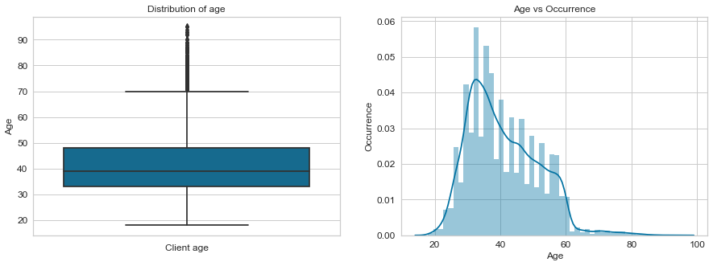

```python
# Outlier detection - Age
Q1 = np.percentile(data["age"], 25, interpolation = 'midpoint')
Q2 = np.percentile(data["age"], 50, interpolation = 'midpoint')
Q3 = np.percentile(data["age"], 75, interpolation = 'midpoint')

print('Q1 25 percentile of the given data is, ', Q1)
print('Q1 50 percentile of the given data is, ', Q2)
print('Q1 75 percentile of the given data is, ', Q3)

IQR = Q3 - Q1
print('Interquartile range is', IQR)

low_lim = Q1 - 1.5 * IQR
up_lim = Q3 + 1.5 * IQR
print('low_limit is', low_lim)
print('up_limit is', up_lim)

print('Number of outliers in Age upper : ', data[data['age']>up_lim]['age'].count())
print('Number of outliers in Age lower : ', data[data['age']<low_lim]['age'].count())
print('% of Outlier in Age upper: ',round(data[data['age']>up_lim]['age'].count()*100/len(data)), '%')
print('% of Outlier in Age lower: ',round(data[data['age']<low_lim]['age'].count()*100/len(data)), '%')

fig, (ax1,ax2)=plt.subplots(1,2,figsize=(15,5))

# boxplot
sns.boxplot(x='age',data=data,orient='v',ax=ax1)
ax1.set_xlabel('Client age', fontsize=12)
ax1.set_ylabel('Age', fontsize=12)
ax1.set_title('Distribution of age', fontsize=12)
ax1.tick_params(labelsize=12)

# distplot
sns.distplot(data['age'],ax=ax2)
ax2.set_xlabel('Age', fontsize=12)
ax2.set_ylabel('Occurrence', fontsize=12)
ax2.set_title('Age vs Occurrence', fontsize=12)
ax2.tick_params(labelsize=12)

# We have clients with all the ages (minimum age 18 to maximum age 95).
# Mean and median have very less difference.
# Age attribute does not have any missing values.
# Age is right skewed. As more number of data points are present on right tail.
```

```
Q1 25 percentile of the given data is,  72.0
Q1 50 percentile of the given data is,  448.0
Q1 75 percentile of the given data is,  1428.0
Interquartile range is 1356.0
low_limit is -1962.0
up_limit is 3462.0
Number of outliers in balance upper :  4712
Number of outliers in balance lower :  17
% of Outlier in balance upper:  10.0 %
% of Outlier in balance lower:  0.0 %
```

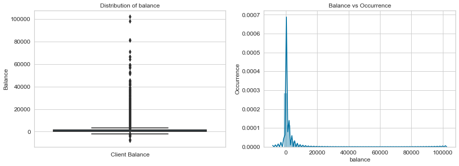

```python
# Outlier detection - Balance
Q1 = np.percentile(data["balance"], 25, interpolation = 'midpoint')
Q2 = np.percentile(data["balance"], 50, interpolation = 'midpoint')
Q3 = np.percentile(data["balance"], 75, interpolation = 'midpoint')

print('Q1 25 percentile of the given data is, ', Q1)
print('Q1 50 percentile of the given data is, ', Q2)
print('Q1 75 percentile of the given data is, ', Q3)

IQR = Q3 - Q1
print('Interquartile range is', IQR)

low_lim = Q1 - 1.5 * IQR
up_lim = Q3 + 1.5 * IQR
print('low_limit is', low_lim)
print('up_limit is', up_lim)

print('Number of outliers in balance upper : ', data[data['balance']>up_lim]['balance'].count())
print('Number of outliers in balance lower : ', data[data['balance']<low_lim]['balance'].count())
print('% of Outlier in balance upper: ',round(data[data['balance']>up_lim]['balance'].count()*100/len(data)), '%')
print('% of Outlier in balance lower: ',round(data[data['balance']<low_lim]['balance'].count()*100/len(data)), '%')

fig, (ax1,ax2)=plt.subplots(1,2,figsize=(15,5))

# boxplot
sns.boxplot(x='balance',data=data,orient='v',ax=ax1)
ax1.set_xlabel('Client Balance', fontsize=12)
ax1.set_ylabel('Balance', fontsize=12)
ax1.set_title('Distribution of balance', fontsize=12)
ax1.tick_params(labelsize=12)

# distplot
sns.distplot(data['balance'],ax=ax2)
ax2.set_xlabel('balance', fontsize=12)
ax2.set_ylabel('Occurrence', fontsize=12)
ax2.set_title('Balance vs Occurrence', fontsize=12)
ax2.tick_params(labelsize=12)
```

```
Q1 25 percentile of the given data is,  103.0
Q1 50 percentile of the given data is,  180.0
Q1 75 percentile of the given data is,  319.0
Interquartile range is 216.0
low_limit is -221.0
up_limit is 643.0
Number of outliers in duration upper :  3235
Number of outliers in duration lower :  0
% of Outlier in duration upper:  7.0 %
% of Outlier in duration lower:  0.0 %
```

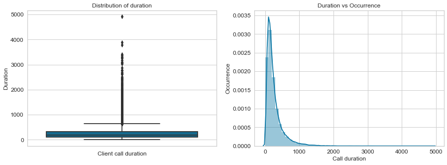

```python
# Outlier detection - Duration
Q1 = np.percentile(data["duration"], 25, interpolation = 'midpoint')
Q2 = np.percentile(data["duration"], 50, interpolation = 'midpoint')
Q3 = np.percentile(data["duration"], 75, interpolation = 'midpoint')

print('Q1 25 percentile of the given data is, ', Q1)
print('Q1 50 percentile of the given data is, ', Q2)
print('Q1 75 percentile of the given data is, ', Q3)

IQR = Q3 - Q1
print('Interquartile range is', IQR)

low_lim = Q1 - 1.5 * IQR
up_lim = Q3 + 1.5 * IQR
print('low_limit is', low_lim)
print('up_limit is', up_lim)

print('Number of outliers in duration upper : ', data[data['duration']>up_lim]['duration'].count())
print('Number of outliers in duration lower : ', data[data['duration']<low_lim]['duration'].count())
print('% of Outlier in duration upper: ',round(data[data['duration']>up_lim]['duration'].count()*100/len(data)), '%')
print('% of Outlier in duration lower: ',round(data[data['duration']<low_lim]['duration'].count()*100/len(data)), '%')

fig, (ax1,ax2)=plt.subplots(1,2,figsize=(15,5))

# boxplot
sns.boxplot(x='duration',data=data,orient='v',ax=ax1)
ax1.set_xlabel('Client call duration', fontsize=12)
ax1.set_ylabel('Duration', fontsize=12)
ax1.set_title('Distribution of duration', fontsize=12)
ax1.tick_params(labelsize=12)

# distplot
sns.distplot(data['duration'],ax=ax2)
ax2.set_xlabel('Call duration', fontsize=12)
ax2.set_ylabel('Occurrence', fontsize=12)
ax2.set_title('Duration vs Occurrence', fontsize=12)
ax2.tick_params(labelsize=12)
```

### Outlier Treatment

##### We can use Capping and Flooring

Decide the upper and lower limit and values above that will be considered as outlier

##### Exponential Smoothening

Extrapolate a curve between 95 and 99 percentile and bring the values to fall on the curves going out of the range P95 and P99

##### Sigma Approach

Identify outliers by capturing all the values falling outside mean +- (sigma)(value)

```python
# Using capping and flooring to treat the outliers for age
np.percentile(data.age,[99])
np.percentile(data.age,[99])[0]
age_uv = np.percentile(data.age,[99])[0]
data[(data.age > age_uv)]
data.age[(data.age > 3*age_uv)] = 3*age_uv
```

```python
# Using capping and flooring to treat the outliers for balance
np.percentile(data.balance,[99])
np.percentile(data.balance,[99])[0]
balance_uv = np.percentile(data.balance,[99])[0]
data[(data.balance > balance_uv)]
data.balance[(data.balance > 3*balance_uv)] = 3*balance_uv
```

```python
# Using capping and flooring to treat the outliers for duration
np.percentile(data.duration,[99])
np.percentile(data.duration,[99])[0]
duration_uv = np.percentile(data.duration,[99])[0]
data[(data.duration > duration_uv)]
data.duration[(data.duration > 3*duration_uv)] = 3*duration_uv
```

```python
# Check the data distribution again to have corrected outliers
data.describe()
```

|  | age | marital | education | default | balance | housing | loan | day | month | duration | campaign | pdays | previous | poutcome | Target |
| --- | --- | --- | --- | --- | --- | --- | --- | --- | --- | --- | --- | --- | --- | --- | --- |
| count | 45211.000000 | 45211.000000 | 45211.000000 | 45211.000000 | 45211.000000 | 45211.000000 | 45211.000000 | 45211.000000 | 45211.000000 | 45211.000000 | 45211.000000 | 45211.000000 | 45211.000000 | 45211.000000 | 45211.000000 |
| mean | 40.936210 | 0.832275 | 1.060516 | 0.018027 | 1350.916649 | 0.555838 | 0.160226 | 15.806419 | 6.144655 | 258.136869 | 2.763841 | 776.645905 | 0.580323 | -0.702661 | 0.116985 |
| std | 10.618762 | 0.608230 | 0.778704 | 0.133049 | 2834.424864 | 0.496878 | 0.366820 | 8.322476 | 2.408034 | 257.113036 | 3.098021 | 265.576597 | 2.303441 | 0.721090 | 0.321406 |
| min | 18.000000 | 0.000000 | -1.000000 | 0.000000 | -8019.000000 | 0.000000 | 0.000000 | 1.000000 | 1.000000 | 0.000000 | 1.000000 | 1.000000 | 0.000000 | -1.000000 | 0.000000 |
| 25% | 33.000000 | 0.000000 | 1.000000 | 0.000000 | 72.000000 | 0.000000 | 0.000000 | 8.000000 | 5.000000 | 103.000000 | 1.000000 | 900.000000 | 0.000000 | -1.000000 | 0.000000 |
| 50% | 39.000000 | 1.000000 | 1.000000 | 0.000000 | 448.000000 | 1.000000 | 0.000000 | 16.000000 | 6.000000 | 180.000000 | 2.000000 | 900.000000 | 0.000000 | -1.000000 | 0.000000 |
| 75% | 48.000000 | 1.000000 | 2.000000 | 0.000000 | 1428.000000 | 1.000000 | 0.000000 | 21.000000 | 8.000000 | 319.000000 | 3.000000 | 900.000000 | 0.000000 | -1.000000 | 0.000000 |
| max | 95.000000 | 2.000000 | 2.000000 | 1.000000 | 39494.700000 | 1.000000 | 1.000000 | 31.000000 | 12.000000 | 3807.000000 | 63.000000 | 900.000000 | 275.000000 | 2.000000 | 1.000000 |